# House Prices - Linear Model

This example will be around a [Kaggle competition](https://www.kaggle.com/c/house-prices-advanced-regression-techniques) where we want to **predict the price of a house** depending on its caracteristics.

### Data Loading

Data comes in 2 files:

1. *train.csv* The training set
2. *test.csv* The final evaluation set.

Our file contains 81 columns and 1460 records

```r
# Set environment
source("utils.R")
set_environment("/Users/deliadelaguila/Documents/GitHub/Catalog")
# Load Data
housing <- read_csv("./Data/House Pricing/data_train.csv", na= "")
head(housing)
```

| Id | MSSubClass | MSZoning | LotFrontage | LotArea | Street | Alley | LotShape | LandContour | Utilities | LotConfig | LandSlope | Neighborhood | Condition1 | Condition2 | BldgType | HouseStyle | OverallQual | OverallCond | YearBuilt | YearRemodAdd | RoofStyle | RoofMatl | Exterior1st | Exterior2nd | MasVnrType | MasVnrArea | ExterQual | ExterCond | Foundation | … |
| --- | --- | --- | --- | --- | --- | --- | --- | --- | --- | --- | --- | --- | --- | --- | --- | --- | --- | --- | --- | --- | --- | --- | --- | --- | --- | --- | --- | --- | --- | --- |
| 1 | 60 | RL | 65 | 8450 | Pave | NA | Reg | Lvl | AllPub | Inside | Gtl | CollgCr | Norm | Norm | 1Fam | 2Story | 7 | 5 | 2003 | 2003 | Gable | CompShg | VinylSd | VinylSd | BrkFace | 196 | Gd | TA | PConc | … |
| 2 | 20 | RL | 80 | 9600 | Pave | NA | Reg | Lvl | AllPub | FR2 | Gtl | Veenker | Feedr | Norm | 1Fam | 1Story | 6 | 8 | 1976 | 1976 | Gable | CompShg | MetalSd | MetalSd | None | 0 | TA | TA | CBlock | … |
| 3 | 60 | RL | 68 | 11250 | Pave | NA | IR1 | Lvl | AllPub | Inside | Gtl | CollgCr | Norm | Norm | 1Fam | 2Story | 7 | 5 | 2001 | 2002 | Gable | CompShg | VinylSd | VinylSd | BrkFace | 162 | Gd | TA | PConc | … |
| 4 | 70 | RL | 60 | 9550 | Pave | NA | IR1 | Lvl | AllPub | Corner | Gtl | Crawfor | Norm | Norm | 1Fam | 2Story | 7 | 5 | 1915 | 1970 | Gable | CompShg | Wd Sdng | Wd Shng | None | 0 | TA | TA | BrkTil | … |
| 5 | 60 | RL | 84 | 14260 | Pave | NA | IR1 | Lvl | AllPub | FR2 | Gtl | NoRidge | Norm | Norm | 1Fam | 2Story | 8 | 5 | 2000 | 2000 | Gable | CompShg | VinylSd | VinylSd | BrkFace | 350 | Gd | TA | PConc | … |
| 6 | 50 | RL | 85 | 14115 | Pave | NA | IR1 | Lvl | AllPub | Inside | Gtl | Mitchel | Norm | Norm | 1Fam | 1.5Fin | 5 | 5 | 1993 | 1995 | Gable | CompShg | VinylSd | VinylSd | None | 0 | TA | TA | Wood | … |

### Data Understanding

Let’s check each one of our 81 variables.

> SalePrice

The property’s sale price in dollars. This is the target variable that we are trying to predict. A numeric variable with normal distribution skewed to the right around 140,000 as mode

```r
get_mode(housing$SalePrice)
```

```
[1] 140000
```

```r
summary(housing$SalePrice)
```

```
   Min. 1st Qu.  Median    Mean 3rd Qu.    Max.
  34900  129975  163000  180921  214000  755000
```

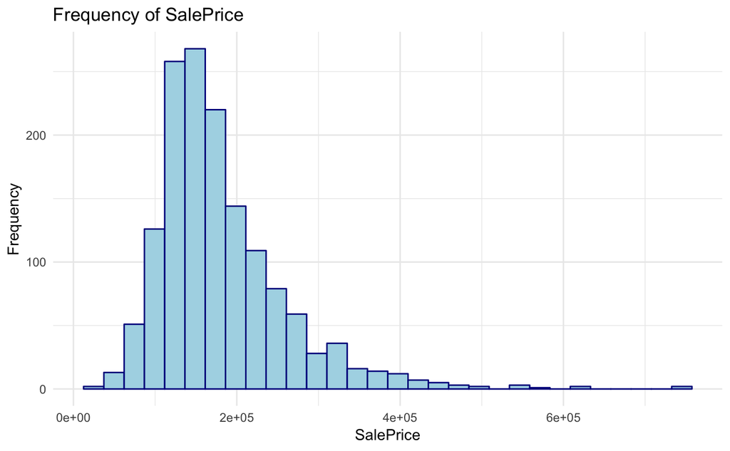

```r
viz_hist(housing, "SalePrice")
```

```r
housing_col <- colnames(housing)
housing %>% select(housing_col[2:5]) %>% summary()
```

```
   MSSubClass     MSZoning     LotFrontage        LotArea
 20     :536   C (all):  10   Min.   : 21.00   Min.   :  1300
 60     :299   FV     :  65   1st Qu.: 59.00   1st Qu.:  7554
 50     :144   RH     :  16   Median : 69.00   Median :  9478
 120    : 87   RL     :1151   Mean   : 70.05   Mean   : 10517
 30     : 69   RM     : 218   3rd Qu.: 80.00   3rd Qu.: 11602
 160    : 63                  Max.   :313.00   Max.   :215245
 (Other):262                  NA's   :259
```

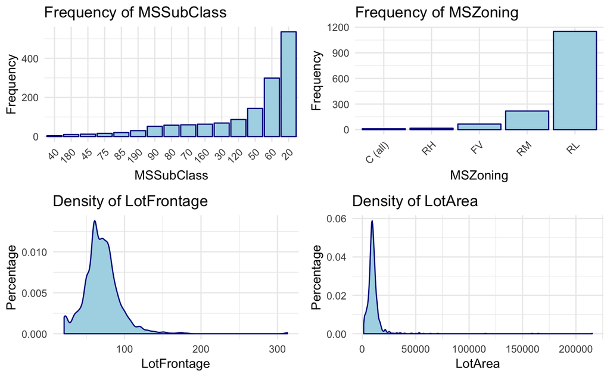

```r
housing$MSSubClass <- as.factor(housing$MSSubClass)
p1 <- viz_bar(housing, housing_col[2])
housing$MSZoning <- as.factor(housing$MSZoning)
p2 <- viz_bar(housing, housing_col[3])
housing$LotFrontage <- as.numeric(housing$LotFrontage)
p3 <- viz_density(housing, housing_col[4])
housing$LotArea <- as.numeric(housing$LotArea)
p4 <- viz_density(housing, housing_col[5])
grid.arrange(p1, p2, p3, p4, nrow = 2)
```

```r
NA
```

LandSlope: Slope of property Neighborhood: Physical locations within Ames city limits Condition1: Proximity to main road or railroad Condition2: Proximity to main road or railroad (if a second is present) BldgType: Type of dwelling HouseStyle: Style of dwelling OverallQual: Overall material and finish quality OverallCond: Overall condition rating YearBuilt: Original construction date YearRemodAdd: Remodel date RoofStyle: Type of roof RoofMatl: Roof material Exterior1st: Exterior covering on house Exterior2nd: Exterior covering on house (if more than one material) MasVnrType: Masonry veneer type MasVnrArea: Masonry veneer area in square feet ExterQual: Exterior material quality ExterCond: Present condition of the material on the exterior Foundation: Type of foundation BsmtQual: Height of the basement BsmtCond: General condition of the basement BsmtExposure: Walkout or garden level basement walls BsmtFinType1: Quality of basement finished area BsmtFinSF1: Type 1 finished square feet BsmtFinType2: Quality of second finished area (if present) BsmtFinSF2: Type 2 finished square feet BsmtUnfSF: Unfinished square feet of basement area TotalBsmtSF: Total square feet of basement area Heating: Type of heating HeatingQC: Heating quality and condition CentralAir: Central air conditioning Electrical: Electrical system 1stFlrSF: First Floor square feet 2ndFlrSF: Second floor square feet LowQualFinSF: Low quality finished square feet (all floors) GrLivArea: Above grade (ground) living area square feet BsmtFullBath: Basement full bathrooms BsmtHalfBath: Basement half bathrooms FullBath: Full bathrooms above grade HalfBath: Half baths above grade Bedroom: Number of bedrooms above basement level Kitchen: Number of kitchens KitchenQual: Kitchen quality TotRmsAbvGrd: Total rooms above grade (does not include bathrooms) Functional: Home functionality rating Fireplaces: Number of fireplaces FireplaceQu: Fireplace quality GarageType: Garage location GarageYrBlt: Year garage was built GarageFinish: Interior finish of the garage GarageCars: Size of garage in car capacity GarageArea: Size of garage in square feet GarageQual: Garage quality GarageCond: Garage condition PavedDrive: Paved driveway WoodDeckSF: Wood deck area in square feet OpenPorchSF: Open porch area in square feet EnclosedPorch: Enclosed porch area in square feet 3SsnPorch: Three season porch area in square feet ScreenPorch: Screen porch area in square feet PoolArea: Pool area in square feet PoolQC: Pool quality Fence: Fence quality MiscFeature: Miscellaneous feature not covered in other categories MiscVal: $Value of miscellaneous feature MoSold: Month Sold YrSold: Year Sold SaleType: Type of sale SaleCondition: Condition of sale

```r
datos <- housing %>% select(-GarageYrBlt, -LotFrontage, -MasVnrArea, -GarageYrBlt, -MoSold, -PoolQC)
datos$MSSubClass <- factor(datos$MSSubClass)
```

### Preprocesamiento

Necesitamos hacer varios pasos de limpieza y preprocesamiento de datos. Aqu?? solo haremos una limpieza y transformaci??n parcial para prop??sitos de nuestro ejemplo.

En primer lugar, nota que muchas de estas variables son categ??ricas. En los casos donde hay datos no disponibles (NA), estas se cuentan como una categor??a m??s, por ejemplo:

```r
table(datos$Alley)
```

[output not shown]

En este caso, la categor??a NA indica que la casa no tiene acceso por callej??n. Igual que en el ejemplo del Titanic, convertimos estas variables con *dummy coding*, o *one hot encoding*.

Podemos usar la funci??n *model.matrix* para hacer este preprocesamiento:

```r
x_datos <- model.matrix(SalePrice ~ ., datos %>% select(-Id))
x_datos <- x_datos[, -1] # quitamos columna de unos
y <- datos$SalePrice
```

Por ejemplo, la variable categ??rica *Alley* (con 3 niveles) corresponde ahora a dos columnas de variables binarias:

```r
x_datos[c(20,21,22,31), c('AlleyNA','AlleyPave')]
```

que puedes comparar con la variable original

```r
datos[c(20,21,22,31), "Alley"]
```

Otro ejemplo es la variable *MSZoning*, cuyas categor??as son:

```r
table(datos$MSZoning)
```

y corresponde a las nuevas variables

```r
x_datos[1:10, 15:18]
```

Aqu?? mostramos las variables que usaremos para nuestros modelos:

```r
colnames(x_datos)
```

Finalmente, la variable que queremos predecir es *SalePrice*:

```r
qplot((datos$SalePrice))
```

[output not shown]

**Nota: veremos m??s adelante m??s pasos de preprocesamiento para mejorar considerablemente el modelo que obtenemos abajo.**

### Regresi??n ridge

Separamos un conjunto de entrenamiento y uno de prueba (1/2 aproximadamente)

```r
set.seed(9911)
indices_entrena <- sample(1:nrow(x_datos), 700)
x_ent <- x_datos[indices_entrena, -1] # primera columna es de 1's, la quitamos
y_ent <- y[indices_entrena] / 1000 # miles de d??lares
x_pr <- x_datos[-indices_entrena, -1]
y_pr <- y[-indices_entrena] / 1000 #miles de d??lares
```

1. Utiliza la funci??n glmnet para ajustar modelos lineales para valores de regularizaci??n. Utiliza la siguiente sucesi??n de valores $\lambda$ de regularizaci??n ridge:

```r
lambda <- exp(seq(-10, 10, 1))
lambda
```

```r
# completa los par??metros que faltan para ajustar los modelos:
mod_ridge <- glmnet(y = y_ent, x = x_ent, alpha = 0, family = "gaussian",
                lambda = lambda)
```

Grafica la traza de los coeficientes:

```r
plot(mod_ridge, xvar= "lambda")
```

[output not shown]

- ??Qu?? pasa con los coeficientes cuando aumenta el valor de lambda? - Tienden a cero
- ??Todos los coeficientes se acercan siempre al valor 0 cuando aumentamos la regularizaci??n? - Haya algunos que aumentan ligeramente pero despues convergen
- ??Por qu?? parece ser que los coeficientes tienen valores casi constantes para valores suficientemente bajos de lambda? -
2. Selecciona el valor de regularizaci??n usando validaci??n cruzada con la funci??n *cv.glmnet*:

```r
# completa los par??metros que faltan:
cv_mod_1 <- cv.glmnet(y = y_ent, x = x_ent, alpha = 0, family = "gaussian",
                      lambda = lambda, nfolds = 10)
plot(cv_mod_1)
```

[output not shown]

??Qu?? valores de la regularizaci??n dan los errores m??s bajos (seg??n la estimaci??n de validaci??n cruzada?)

```r
cv_mod_1$lambda.min
max(cv_mod_1$lambda)

cv_mod_1$lambda.1se
```

3. Selecciona un modelo con baja regularizaci??n, con el valor ??ptimo seg??n validaci??n cruzada, y otro con mucha regularizaci??n (utiliza las lambdas mostradas abajo). Eval??a el error de predicci??n (ra??z de error cuadr??tico media) seg??n la muestra de prueba que separamos arriba:

```r
# rellena tres valores, uno con muy baja regularizaci??n , uno con regularizaci??n
#??ptima seg??n validaci??n cruzada, y otro con demasiada regularizaci??n:
lambda_pred <- c(lambda[1] , cv_mod_1$lambda.min, max(cv_mod_1$lambda))
lambda_pred
```

Calcula errores de prueba

```r
preds_1 <- predict(mod_ridge, newx = x_pr, s = lambda_pred[1])
preds_2 <- predict(mod_ridge, newx = x_pr, s = lambda_pred[2])
preds_3 <- predict(mod_ridge, newx = x_pr, s = lambda_pred[3])
sqrt(mean((preds_1 - y_pr)^2))
sqrt(mean((preds_2 - y_pr)^2))
sqrt(mean((preds_3 - y_pr)^2))
#
#
```

[output not shown]

- ??Qu?? modelo tiene el error m??s bajo de prueba? ??Por qu?? esperar??as esto?

Grafica predicciones del modelo con menor error contra los valores observados

```r
# Haz tu gr??fica aqu??
plot(preds_1,y_pr)
```

```r
coefs_reg_baja <- predict(mod_ridge,
                          s = lambda_pred[1], type= "coefficients")
coefs_reg_baja <- coefs_reg_baja[-1,1] # tomamos la primera columna y quitamos intercept
# rellena aqu??
coefs_reg_opt <- predict(mod_ridge,
                          s = lambda_pred[3], type= "coefficients")
coefs_reg_opt <- coefs_reg_opt[-1,1]

# ahora grafica estos coeficientes en una gr??fica x-y:
plot(coefs_reg_opt,coefs_reg_baja)
```

```r
qplot(coefs_reg_opt, coefs_reg_baja) +
  xlab('Coeficientes Optimos') +
  ylab('Coeficientes estimados') +
  geom_abline(intercept=0, slope =1) +
  xlim(c(-0.5,0.5))+ ylim(c(-0.5,0.5))
```

- ??Qu?? puedes decir acerca de la dispersi??n de los coeficientes del modelo con baja regularizaci??n en comparaci??n al de regularizaci??n media? ??Cu??l es el rango de los coeficientes del modelo con baja regularizaci??n?
5. Compara algunos coeficientes de dos modelos, el de regularizaci??n baja con uno de regularizaci??n ??ptima seg??n validaci??n cruzada

Por ejemplo, compara los coeficientes relacionados con el garage (tipo, terminados, Calidad, Condici??n, coches y ??rea):

```r
nombres <- rownames(coefs_reg_baja)
coef_garage_baja <- coefs_reg_baja[, 1][str_detect(nombres, "Garage")]
coef_garage_baja
```

- ??Qu?? efecto puede tener esta variable en tus predicciones? Considera que el tama??o de los coeficientes est?? en miles de d??lares,
- ??Cu??l es el valor mediano de las casas en el conjunto de entrenamiento (y)? ??Los efectos del inciso anterior te parecen razonables?

Repite para regularizaci??n ??ptima seg??n validaci??n cruzada:

```r
# calcula para los coeficientes del modelo m??s regularizado
```

- ??Qu?? efecto puede tener esta variable en tus predicciones? Considera que el tama??o de los coeficientes est?? en miles de d??lares?
- ??Cu??l es el valor mediano de las casas en el conjunto de entrenamiento (y)? ??Los efectos del inciso anterior te parecen razonables?